# Where Are The Women?

By: Maggie Welsh, Marissa Freed, and Natasha Rosenthal

May 7, 2018

## Female Representation in Films and Reviews is Seriously Lacking

The underrepresentation of women in the film industry is hard to ignore. According to the [2010 U.S. Census]{https://www.census.gov/prod/cen2010/briefs/c2010br-03.pdf}, the population of the United States is 50.8% female, 49.2% male. This is not what we see when we walk into a movie theater.

To demonstrate this disparity, we looked to data on the ratio of women to men in movie casts in relation to the gross profit from films’ opening weekends and IMDb ratings corresponding to these films. We found that across the board, men are overrepresented in both the top grossing films and top rated IMDb films.

### SQL Queries

```r
gendergross <- imdb %>%
  dbGetQuery("SELECT n.name as actor, gender, person_id, ci.movie_id, person_role_id as char_id,  cn.name as character_name, title, production_year, mi.info as language, mi2.info as gross
from imdb.name n
join imdb.cast_info ci on n.id = ci.person_id
join imdb.char_name cn on cn.id = ci.person_role_id
join imdb.title t on t.id = ci.movie_id
JOIN imdb.movie_info mi ON mi.movie_id = ci.movie_id
JOIN imdb.movie_info mi2 ON mi2.movie_id = ci.movie_id
WHERE mi.info_type_id IN (4) AND mi.info = 'English'
  AND kind_id = 1
  AND mi2.info_type_id = 108 AND mi2.info like '%(USA%'
  and production_year > 1999
ORDER BY title;")
#join actor names to their characters, character names, the titles of the films, as well as language of films, and all films with opening weekend box office gross data. then filter for just English films premiering in the USA after 1999 (so only 21st century).

english_table <- imdb %>%
  dbGetQuery("SELECT t.id, title, kind_id, production_year, movie_id, info_type_id, info AS language
FROM imdb.title t
join imdb.movie_info m on t.id = m.movie_id
having kind_id = 1
and info like '%English%'
and production_year > 1999
and info_type_id = 4;")
#join title of films to movie.info to filter out non-english films

gross_table <- imdb %>%
  dbGetQuery("SELECT t.id, title, kind_id, production_year, info_type_id, info
FROM imdb.title t
join imdb.movie_info m on t.id = m.movie_id
having kind_id = 1
and production_year > 1999
and info_type_id = 108
and info like '%USA%';")
#join same as above but filtering USA opening weekend box office grosses

votes_table <- imdb %>%
  dbGetQuery("SELECT t.id, t.title, t.production_year,
  miv.info AS votes
FROM title t
JOIN movie_info_idx AS miv ON miv.movie_id = t.id
WHERE t.kind_id = 1
  AND miv.info_type_id = 100
  AND miv.info > 75000;")
#join title and movie info to find films with 100k + votes on IMDb

ratings_table <- imdb %>%
  dbGetQuery("SELECT t.id, t.title, t.production_year, mir.info AS rating
FROM title t
JOIN movie_info_idx AS mir ON mir.movie_id = t.id
WHERE t.kind_id = 1
  AND mir.info_type_id = 101;")
#find ratings for films
```

### Code for Data Wrangling

```r
gendergross <- gendergross %>%
  mutate(gross_string = str_extract(gross, "^\\$[0-9]+,[0-9]{3},[0-9]{3}"),
         gross_numeric = parse_number(gross_string)) %>% #Used regular expressions to create a new column where gross is a numeric vector
  filter(grepl("\\(USA\\)", gross)) %>% #Used regular expressions to filter the info column to movies opening in the USA
  arrange(desc(gross_numeric))


char_total <- gendergross %>%
  group_by(movie_id) %>%
  summarize(total_people = n_distinct(char_id)) #find total number of actors listed for each movie

gender_total <- gendergross %>%
  group_by(movie_id, gender) %>%
  summarize(gendertot = n_distinct(char_id)) %>% #find total number of actors listed for each movie by gender
  full_join(char_total, by = "movie_id") #join with char_total to get column with total actors for each moview

gender_total1 <- gender_total %>%
  filter(gender == 'f') %>%
  group_by(movie_id) %>%
  mutate(ratiof = gendertot/total_people) #create column with the ratio of women to men for each movie
```

```r
joined_gross <- gross_table %>%
  inner_join(english_table, by = c("id", "title", "kind_id", "production_year")) %>% #join table showing english movies with table showing gross
  mutate(gross_string = str_extract(info, "^\\$[0-9]+,[0-9]{3},[0-9]{3}"),
         gross_numeric = parse_number(gross_string)) %>% #Used regular expressions to create a new column where gross is a numeric vector
  filter(grepl("\\(USA\\)", info)) %>% #Used regular expressions to filter the info column to movies opening in the USA
  filter(grepl("screens\\)", info)) %>% #Used regular expressions to filter the info column to ones that show how many screens the movie was shown on in the opening weekend
  arrange(desc(gross_numeric))

gender_gross <- joined_gross %>%
  full_join(gender_total1, by = "movie_id") %>% #join previous table with table showing ratios of women to men
  select(c(1, 2, 4, 6, 11, 12, 13, 14, 15))%>% #remove extraneous columns
  arrange(desc(gross_numeric)) %>% #show in descending order
  head(n = 100) #limit to 100 rows to get only top 100 grossing movies in opening weekend
```

```r
joined_votes <- votes_table %>%
  inner_join(ratings_table, by = c("id", "title", "production_year")) %>% #join the table showing imdb ratings with the table showing votes
  filter(production_year > 1999) %>% #filter show only showing movies released in 2000 or later
  rename(movie_id = id) %>%
  arrange(desc(rating)) #arrange from highest to lowest rating
```

```r
gendervotes <- joined_votes %>%
  inner_join(gender_total1, by ="movie_id") %>% #join table with votes and ratings with table with ratio of women to men
  head(n = 100) #show top 100 rated movies
```

### Below are the top 100 highest grossing films from opening weekend:

```r
gender_gross
```

|  | id | title | production_year | info | gross_numeric | gender | gendertot | total_people | ratiof |
| --- | --- | --- | --- | --- | --- | --- | --- | --- | --- |
| 1 | 4260166 | Star Wars: Episode VII - The Force Awakens | 2015 | $247,966,675 (USA) (20 December 2015) (4134 screens) | 247966675 | f | 41 | 120 | 0.34166667 |
| 2 | 3787790 | Jurassic World | 2015 | $208,806,270 (USA) (12 June 2015) (4274 screens) | 208806270 | f | 51 | 140 | 0.36428571 |
| 3 | 4316706 | The Avengers | 2012 | $207,438,708 (USA) (6 May 2012) (4,349 screens) | 207438708 | f | 35 | 106 | 0.33018868 |
| 4 | 3313672 | Avengers: Age of Ultron | 2015 | $191,271,109 (USA) (1 May 2015) (4276 screens) | 191271109 | f | 40 | 114 | 0.35087719 |
| 5 | 3400744 | Captain America: Civil War | 2016 | $179,139,142 (USA) (8 May 2016) (4,226 screens) | 179139142 | f | 37 | 153 | 0.24183007 |
| 6 | 3334758 | Beauty and the Beast | 2017 | $174,750,616 (USA) (19 March 2017) (4210 screens) | 174750616 | f | 36 | 81 | 0.44444444 |
| 7 | 3759369 | Iron Man Three | 2013 | $174,144,585 (USA) (7 May 2013) (4253 screens) | 174144585 | f | 63 | 185 | 0.34054054 |
| 8 | 3759369 | Iron Man Three | 2013 | $174,144,585 (USA) (5 May 2013) (4,253 screens) | 174144585 | f | 63 | 185 | 0.34054054 |
| 9 | 3679815 | Harry Potter and the Deathly Hallows: Part 2 | 2011 | $169,189,427 (USA) (17 July 2011) (4,375 screens) | 169189427 | f | 47 | 116 | 0.40517241 |
| 10 | 3330905 | Batman v Superman: Dawn of Justice | 2016 | $166,007,347 (USA) (27 March 2016) (4,242 screens) | 166007347 | f | 84 | 281 | 0.29893238 |

[output cut: 90 more lines]

### Below are the top 100 IMDb rated films:

```r
gendervotes
```

|  | movie_id | title | production_year | votes | rating | gender | gendertot | total_people | ratiof |
| --- | --- | --- | --- | --- | --- | --- | --- | --- | --- |
| 1 | 4339102 | The Dark Knight | 2008 | 1846568 | 9.0 | f | 34 | 172 | 0.19767442 |
| 2 | 4383711 | The Lord of the Rings: The Return of the King | 2003 | 1337090 | 8.9 | f | 10 | 67 | 0.14925373 |
| 3 | 3747868 | Inception | 2010 | 1636262 | 8.8 | f | 16 | 54 | 0.29629630 |
| 4 | 4383708 | The Lord of the Rings: The Fellowship of the Ring | 2001 | 1357428 | 8.8 | f | 16 | 63 | 0.25396825 |
| 5 | 4383714 | The Lord of the Rings: The Two Towers | 2002 | 1210758 | 8.7 | f | 11 | 70 | 0.15714286 |
| 6 | 3755633 | Interstellar | 2014 | 1102826 | 8.6 | f | 8 | 39 | 0.20512821 |
| 7 | 3756812 | Intouchables | 2011 | 582657 | 8.6 | f | 11 | 35 | 0.31428571 |
| 8 | 4200606 | Sen to Chihiro no kamikakushi | 2001 | 478946 | 8.6 | f | 11 | 29 | 0.37931034 |
| 9 | 3649367 | Gladiator | 2000 | 1085419 | 8.5 | f | 3 | 53 | 0.05660377 |
| 10 | 3944746 | Memento | 2000 | 933321 | 8.5 | f | 5 | 14 | 0.35714286 |

[output cut: 90 more lines]

[Rogue One: A Star Wars Story *(2016) poster prominently displaying the female lead. Below her are the men that make up the rest of the cast: this movie has a female to male cast ratio of just 13.9%.*]{https://starwarsblog.starwars.com/wp-content/uploads/2016/10/rogueone_onesheetA.jpg}

### Below are the average as well as the five movies with the lowest and highest ratio of women to men from the top 100 grossing movies:

```r
gender_gross %>%
  summarize(average_f = mean(ratiof))
```

| average_f |
| --- |
| 0.3079047 |

```r
gender_gross %>%
  arrange(desc(ratiof)) %>%
  select(c(2,3,4,9)) %>%
  head(n=5)
```

|  | title | production_year | info | ratiof |
| --- | --- | --- | --- | --- |
| 1 | The Twilight Saga: Breaking Dawn - Part 1 | 2011 | $138,122,261 (USA) (20 November 2011) (4,061 screens) | 0.4905660 |
| 2 | Fifty Shades of Grey | 2015 | $94,395,000 (USA) (15 February 2015) (3,646 screens) | 0.4761905 |
| 3 | Doctor Strange | 2016 | $85,058,311 (USA) (6 November 2016) (3,882 screens) | 0.4754098 |
| 4 | Spider-Man 3 | 2007 | $151,116,516 (USA) (6 May 2007) (4,252 screens) | 0.4682540 |
| 5 | It | 2017 | $123,403,419 (USA) (10 September 2017) (4,103 screens) | 0.4583333 |

```r
gender_gross %>%
  arrange(ratiof) %>%
  select(c(2,3,4,9)) %>%
  head(n=5)
```

|  | title | production_year | info | ratiof |
| --- | --- | --- | --- | --- |
| 1 | Fury | 2014 | $82,251,953 (USA) (4 December 2014) (3313 screens) | 0.07438017 |
| 2 | Pearl Harbor | 2001 | $75,177,654 (USA) (27 May 2001) (3,214 screens) | 0.09259259 |
| 3 | The Hobbit: An Unexpected Journey | 2012 | $84,617,303 (USA) (16 December 2012) (4,045 screens) | 0.09836066 |
| 4 | Pirates of the Caribbean: At World's End | 2007 | $139,802,190 (USA) (27 May 2007) (4,362 screens) | 0.10377358 |
| 5 | Rogue One | 2016 | $155,081,681 (USA) (18 December 2016) (4157 screens) | 0.13934426 |

### Below are average as well as the five movies with the lowest and highest ratio of women to men from the top 100 IMDb rated movies:

```r
gendervotes %>%
  summarize(average_f = mean(ratiof))
```

| average_f |
| --- |
| 0.2883364 |

```r
gendervotes %>%
  arrange(desc(ratiof)) %>%
  select(c(2,3,5,9)) %>%
  head(n=5)
```

|  | title | production_year | rating | ratiof |
| --- | --- | --- | --- | --- |
| 1 | The Help | 2011 | 8.1 | 0.5555556 |
| 2 | Black Swan | 2010 | 8.0 | 0.5306122 |
| 3 | Her | 2013 | 8.0 | 0.5180723 |
| 4 | La La Land | 2016 | 8.2 | 0.5140187 |
| 5 | Donnie Darko | 2001 | 8.1 | 0.5102041 |

```r
gendervotes %>%
  arrange(ratiof) %>%
  select(c(2,3,5,9)) %>%
  head(n=5)
```

|  | title | production_year | rating | ratiof |
| --- | --- | --- | --- | --- |
| 1 | Hacksaw Ridge | 2016 | 8.2 | 0.04587156 |
| 2 | Dunkirk | 2017 | 8.3 | 0.05000000 |
| 3 | Gladiator | 2000 | 8.5 | 0.05660377 |
| 4 | Snatch | 2000 | 8.3 | 0.06451613 |
| 5 | Pirates of the Caribbean: The Curse of the Black Pearl | 2003 | 8.0 | 0.10294118 |

It’s important to note that IMDb ratings do not always equally represent the opinions of men and women. An [article]{https://fivethirtyeight.com/features/what-if-online-movie-ratings-werent-based-almost-entirely-on-what-men-think/} from FiveThirtyEight, aptly titled “What if Online Movie Ratings Weren’t Based Almost Entirely On What Men Think?” discusses the significant bias on men’s’ opinions that is apparent in IMDb ratings, as well as the implications of this disparity.

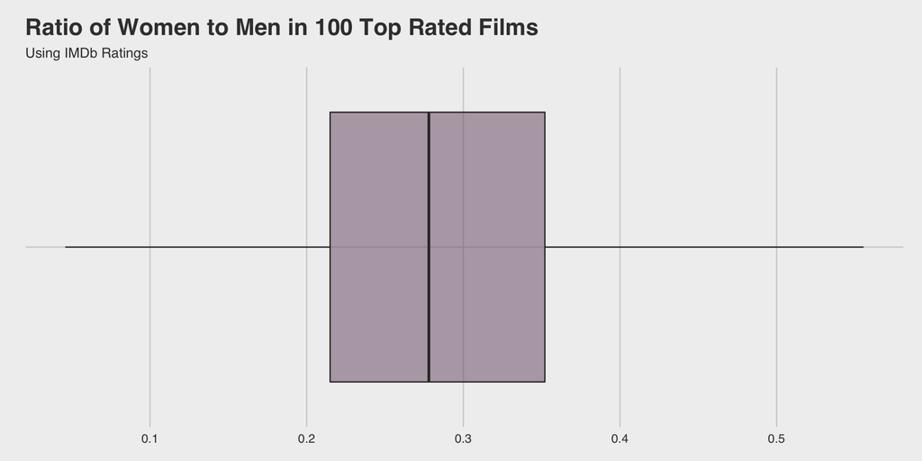

```r
ggplot(gendervotes, aes(x="", y = ratiof))+
  geom_boxplot(alpha = 0.5, fill = "#78566F") +
  coord_flip() +
  labs(x = NULL, y = "Ratio of Women to Men", title = "Ratio of Women to Men in 100 Top Rated Films", subtitle = "Using IMDb Ratings") +
  theme_fivethirtyeight()
```

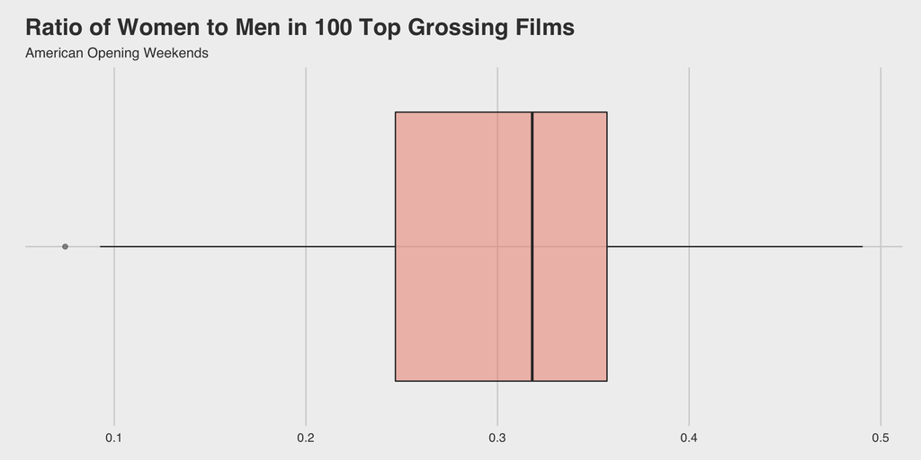

```r
ggplot(gender_gross, aes(x="", y = ratiof))+
  geom_boxplot(alpha = 0.5, fill = "#EE8A78") +
  coord_flip() +
  labs(x = NULL, y = "Ratio of Women to Men", title = "Ratio of Women to Men in 100 Top Grossing Films", subtitle = "American Opening Weekends") +
  theme_fivethirtyeight()
```

Since 2000, the average ratio of women to men in the top opening weekend grossing films was just 30.8%. Even the film with the highest ratio, *The Twilight Saga: Breaking Dawn – Part 1* (2011), a fantasy/drama film, had a ratio of less than half, at 49%. *Fury* (2014), a war film, recorded a dismal 7.4%–the lowest ratio out of the highest opening weekend gross films. This follows the trend of female-marketed films having a more realistic ratio than that of male-marketed films.

Notably, *Rogue One: A Star Wars Story* (2016) had the fifth lowest ratio of highest grossing films, with just 13.9%, despite being heavily marketed as a female-led film. *Rogue One*’s female lead was a topic of much controversy when the film was released. One [article]{https://www.theatlantic.com/entertainment/archive/2016/12/with-rogue-one-the-star-wars-franchise-gets-even-more-feminist/510944/} heralds the film as a “full feminist,” citing the many impressive feats accomplished by Jyn, the female lead, as proof of the film’s progressiveness. [Another]{https://www.smh.com.au/lifestyle/why-its-not-enough-for-feminist-films-to-have-a-great-female-lead-20170118-gtu244.html} claims that a strong female lead is “not enough” to make a film feminist, highlighting the fact that Jyn’s male ally has more lines than her. The film’s low cast ratio of women to men is a disappointing indication that even films that at once appear to be feminist works may in fact be less female-focused than they claim.

This connects, unquestionably, to larger problems of representation concerning gender and race in popular media. As we’ve seen with recent movements like #OscarsSoWhite and #MeToo, Hollywood has a serious problem representing the voices of minorities. Many other media industries experience these same issues. One that has recently come into our cultural discussion is competitive esports, which experiences, unsurprisingly, a severe lack of representation, especially with regard to women. [The Overwatch League]{https://overwatchleague.com/en-us/}, perhaps today’s most popular esports league, has 129 players, only one of which is female. While many take issue with this and urge the organization to hire more women, they may fail to recognize the complexity of the issue.

[*The players from the Overwatch League team Shanghai Dragons. Se-yeon “Geguri” Kim (top right) is the sole female competitor in the Overwatch League.*]{https://www.vpesports.com/wp-content/uploads/2018/04/DauyBZQVwAAFtBp.jpg}

Factors contributing to this severe lack of women in competitive esports include possible sexism on the part of the organization, of course, but also the lack of women playing at a professional skill level, the tendency for popular games to be tailored to men, our cultural emphasis on gaming as a boy’s hobby, and the larger gaming community’s propensity for sexism. Although the Overwatch League has shown that they’re willing to hire female players, these complications make the prospect of doing so, in many cases, impossible.

The film industry is no different. While some may argue that these findings are the result of movie executives’ unwillingness to hire women at the same rates that they hire men, this would be a gross oversimplification of the issue. The large, persisting issue of minority representation in Hollywood and the film industry is a complex problem that will require an equally complex solution. While it’s easy to suggest that Hollywood needs only to hire more women to fix this issue, this is not a realistic and comprehensive solution. Instead, we need to focus on access to film education, cultural attitudes toward women in the industry, and hiring practices at every level.